# Kraustralia

[figure not shown]

### Let’s Go Anywhere

*16 January 2015*  
Seattle, WA

We bid adieu to Alley 24, our home for [… (click for more)](https://www.andykrause.com/kraustralia/kraustralia_full.html#kraustralia_0).

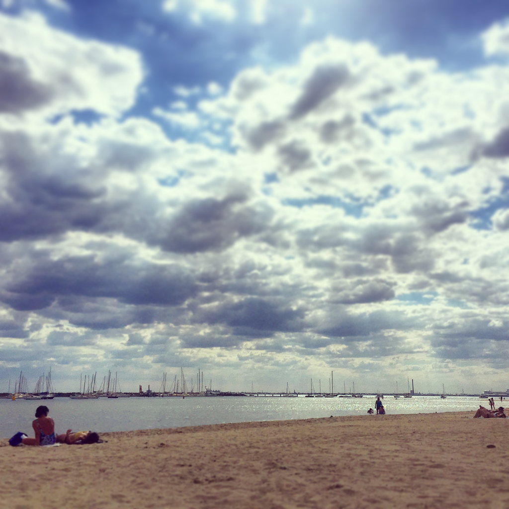

### Arrival in Melbourne

*22 January 2015*  
Melbourne, Vic  
A full twenty-four hours after leaving Seattle – via our scheduled Los Angeles stop and our unscheduled Sydney one – we arrived in Melbourne. Immigration and customs took a matter of minutes, either a nod to Australian efficiency or, possibly, apathy. Our journey to the taxi stand took us outside and into the heat, a very welcome 36C (97F) heat. As our cab headed into the city our fatigue and exhaustion melted away as our new home came into view out of the car [… (click for more)](https://www.andykrause.com/kraustralia/kraustralia_full.html#kraustralia_1).

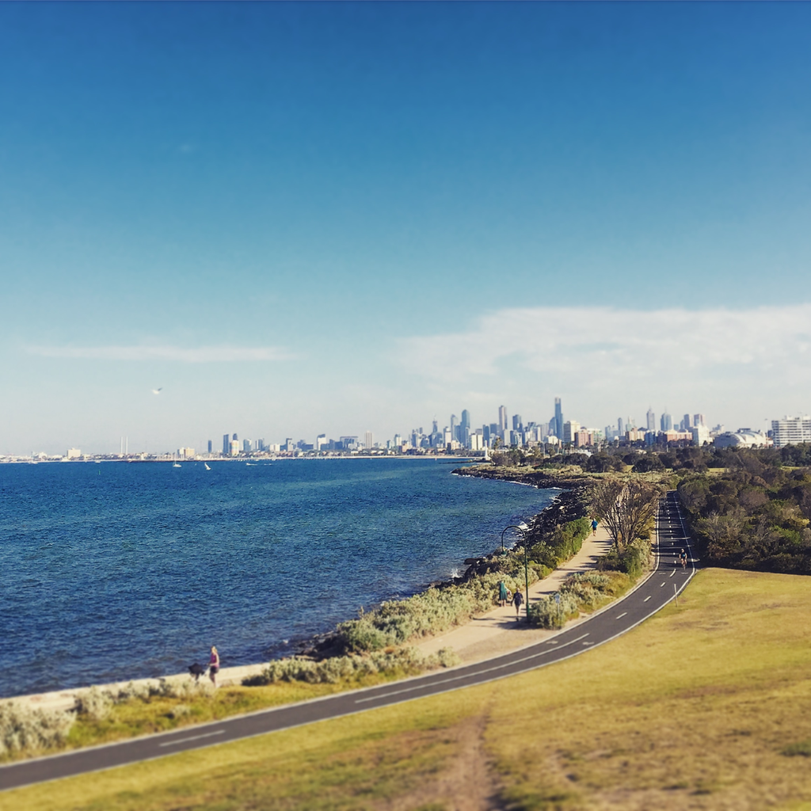

### Settling In

*23 January 2015*  
Melbourne, Vic

On our first full day, we dove right into the culture with a cup of morning tea out on our deck. The cool, marine breeze of the early morning soon gave way to summer heat. We took a long walk along the Bay Trail down to Point Ormond. The way back was warm; the heat, the sweat, the sun on our skin all so wonderful after the last few months in wet and cool Pacific Northwest. We live here now.

by [Andy Krause](https://github.com/andykrause/)

*andy@andykrause.com*